# Exercise 1: Pooling (Solution)

## Skovgaard-Olsen et al. (2016): The Relevance Effect and Conditionals

- Conditional = *if-then* statement; e.g., If global warning continues, London will be flooded.
- Bayesian reasoning often assumes ‘the Equation’: *P*(if *A* then *B*) = *P*(*B*|*A*)
- Our question: Does the Equation hold?
- 94 (of 348) participants recruited via `crowdflower.com` worked on 12 items.
- Participant first saw a vignette:

  > Sophia’s scenario: Sophia wishes to find a nice present for her 13-year-old son, Tim, for Christmas. She is running on a tight budget, but she knows that Tim loves participating in live role-playing in the forest and she is really skilled at sewing the orc costumes he needs. Unfortunately, she will not be able to afford the leather parts that such costumes usually have, but she will still be able to make them look nice.
- Then we asked participant for their rating for the conditional probability *P*(*B*|*A*) on the probability scale from 0% to 100%:

  > Suppose Sophia makes Tim an orc costume. Under this assumption, how probable is it that the following sentence is true:  
  > Tim will be excited about his present.
- On the next page, we asked participant for their rating of the probability of the conditional *P*(if *A* then *B*) on the probability scale from 0% to 100%:

  > Could you please rate the probability that the following sentence is true:  
  > IF Sophia makes Tim an orc costume, THEN he will be excited about his present.

### Design

Research question: Does the Equation (i.e., *P*(if *A* then *B*) = *P*(*B*|*A*)) hold?

For each item, participants provide idiosyncratic estimates of *P*(if *A* then *B*) (`if_A_then_B`) and *P*(*B*|*A*) (`B_given_A`).  
Each participant worked on 12 items, that is each participant provided 12 estimates of *P*(if *A* then *B*) (`if_A_then_B`) and *P*(*B*|*A*) (`B_given_A`).

Data prepared for this exercise is available in the folder (full data available at: https://osf.io/j4swp/)

# Exercise 1: Analyse the data using the no-pooling approach

- Calculate the regression between *P*(if *A* then *B*) and *P*(*B*|*A*) separately for each participant.
- Does this analysis suggest that there is an overall association between the two variables? If so, how strong is this relationship?

## Getting started:

Don’t forget to **restart R**: `Session` -> `Restart R`

Some package we might need.

```r
library("tidyverse")
theme_set(theme_bw())
library("broom") # not automatically loaded
```

I have already downloaded the data from the OSF and prepared it according to the descriptions found there. The prepared data is in `dat`.

```r
# Run complete chunk: Ctrl+Shift+Enter

# You might need to set the correct working directory via the menu:
# Session -> Set Working Directory -> To Source File Location

afex::set_sum_contrasts() # just in case we set orthogonal contrasts

load("ssk16_dat_prepared_ex1.rda") # data preapred in 'prepare_data.R'
str(dat1)
```

```
'data.frame':   376 obs. of  7 variables:
 $ p_id         : Factor w/ 94 levels "102_P(if,then)",..: 63 63 63 63 64 64 64 64 65 65 ...
 $ i_id         : Factor w/ 12 levels "1","2","3","4",..: 1 7 10 12 2 4 5 8 1 3 ...
 $ B_given_A    : num  52 79 79 77 98 98 97 90 28 100 ...
 $ B_given_A_c  : num  0.02 0.29 0.29 0.27 0.48 0.48 0.47 0.4 -0.22 0.5 ...
 $ if_A_then_B  : num  52 84 94 81 95 97 90 95 28 100 ...
 $ if_A_then_B_c: num  0.02 0.34 0.44 0.31 0.45 0.47 0.4 0.45 -0.22 0.5 ...
 $ rel_cond     : Factor w/ 1 level "PO": 1 1 1 1 1 1 1 1 1 1 ...
```

Variables in the data:

- `p_id`: participant identifier
- `i_id`: item identifier (i.e., id of vignette)
- `B_given_A`: original *P*(*B*|*A*)
- `B_given_A_c`: *P*(*B*|*A*) centered at midpoint of scale (as used in paper)
- `if_A_then_B`: original *P*(if *A* then *B*)
- `if_A_then_B_c`: *P*(if *A* then *B*) centered at midpoint of scale (as used in paper)
- `rel_cond`: relevance condition. Has only one level here, can be ignored.

## Complete-Pooling Approach

```r
m0 <- lm(if_A_then_B ~ B_given_A, dat1)
summary(m0)
```

```
Call:
lm(formula = if_A_then_B ~ B_given_A, data = dat1)

Residuals:
    Min      1Q  Median      3Q     Max
-69.513  -7.824   0.811   2.798  81.554

Coefficients:
            Estimate Std. Error t value Pr(>|t|)
(Intercept) 18.44616    1.96690   9.378   <2e-16 ***
B_given_A    0.78756    0.02659  29.624   <2e-16 ***
---
Signif. codes:  0 ‘***’ 0.001 ‘**’ 0.01 ‘*’ 0.05 ‘.’ 0.1 ‘ ’ 1

Residual standard error: 17.65 on 374 degrees of freedom
Multiple R-squared:  0.7012,    Adjusted R-squared:  0.7004
F-statistic: 877.6 on 1 and 374 DF,  p-value: < 2.2e-16
```

When we completely ignore the dependencies in the data, we can see a clear relationship between the IV and DV. The regression parameter estimate for `B_given_A` is clearly significant (i.e., different from 0) but also not too far away from 1.0. If it were 1.0, this would mean that *P*(if *A* then *B*) = *P*(*B*|*A*) would hold exactly.

Before the next step, let’s take a look at the data. It suggests indeed that the relationship between IV and DV. But does it hold when looking at the data of individual participants?

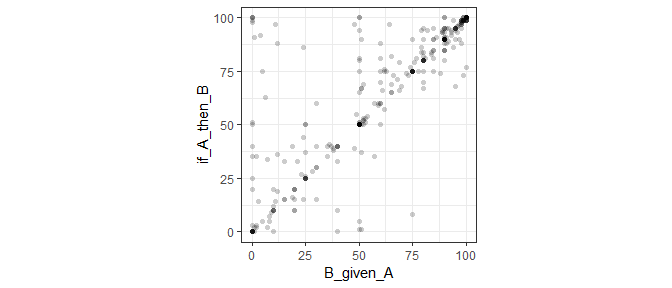

```r
ggplot(data = dat1) +
  geom_point(mapping = aes(x = B_given_A, y = if_A_then_B), alpha = 0.2, pch = 16) +
  coord_fixed()
```

## Full Instructions

- Your task is to calculate the regression parameter (i.e., slope, potentially also the intercept) for each participant (i.e., relationship of `if_A_then_B` and `B_given_A` for each `p_id`).
- Then investigate the distribution of resulting regression parameters. Perform this investigation in a graphical way and also statistically (i.e., using `lm`).
- The goal of this exercise is to combine your knowledge of the `tidyverse` and use it to solve the aforementioned task.
- In case you need some inspiration for `dplyr` and `broom`, you might want to take a look at chapter 25 (especially 25.2.1, 25.2.2, 25.2.3) of Wickham and Grolemund (2017) see: http://r4ds.had.co.nz/many-models.html

```r
ex1_no_pooling_estimates <- dat1 %>%
  group_by(p_id) %>%
  do(tidy(lm(if_A_then_B ~ B_given_A, .)))
```

[output not shown]

```r
head(ex1_no_pooling_estimates)
```

| p_id | term | estimate | std.error | statistic | p.value |
| --- | --- | --- | --- | --- | --- |
| 102_P(if,then) | (Intercept) | 0.01152738 | 4.49173976 | 0.00256635 | 0.998185319 |
| 102_P(if,then) | B_given_A | 0.97859201 | 0.07824749 | 12.50636976 | 0.006332814 |
| 107_P(if,then) | (Intercept) | -14.90540541 | 4.26673006 | -3.49340249 | 0.073073242 |
| 107_P(if,then) | B_given_A | 1.16486486 | 0.06821313 | 17.07684176 | 0.003411599 |
| 108_P(if,then) | (Intercept) | 76.77950794 | 18.66498224 | 4.11355912 | 0.054325954 |
| 108_P(if,then) | B_given_A | 0.20367487 | 0.25869996 | 0.78730151 | 0.513588988 |

```r
NA
```

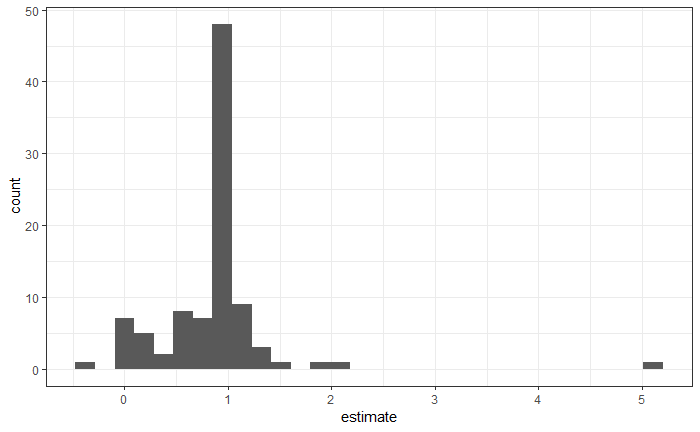

```r
ex1_slopes <- ex1_no_pooling_estimates %>%
  filter(term == "B_given_A")

ggplot(ex1_slopes, aes(estimate)) +
  geom_histogram(bins = 30)
```

```r
summary(lm(estimate ~ 1, ex1_slopes))
```

```
Call:
lm(formula = estimate ~ 1, data = ex1_slopes)

Residuals:
    Min      1Q  Median      3Q     Max
-1.1807 -0.2006  0.1049  0.1254  4.3072

Coefficients:
            Estimate Std. Error t value Pr(>|t|)
(Intercept)  0.87464    0.06204    14.1   <2e-16 ***
---
Signif. codes:  0 ‘***’ 0.001 ‘**’ 0.01 ‘*’ 0.05 ‘.’ 0.1 ‘ ’ 1

Residual standard error: 0.6015 on 93 degrees of freedom
```

# Exercise 2: Analysing more conditions using complete pooling and no-pooling approach

The study of Skovgaard-Olsen et al. contained a further manipulation not considered so far. These additional data, `dat2`, can be found in file `ssk16_dat_prepared_ex2.rda`.

```r
load("ssk16_dat_prepared_ex2.rda")
str(dat2)
```

```
'data.frame':   752 obs. of  7 variables:
 $ p_id         : Factor w/ 94 levels "102_P(if,then)",..: 63 63 63 63 63 63 63 63 64 64 ...
 $ i_id         : Factor w/ 12 levels "1","2","3","4",..: 1 2 7 8 9 10 11 12 2 4 ...
 $ B_given_A    : num  52 60 79 0 51 79 80 77 98 98 ...
 $ B_given_A_c  : num  0.02 0.1 0.29 -0.5 0.01 0.29 0.3 0.27 0.48 0.48 ...
 $ if_A_then_B  : num  52 1 84 0 51 94 1 81 95 97 ...
 $ if_A_then_B_c: num  0.02 -0.49 0.34 -0.5 0.01 0.44 -0.49 0.31 0.45 0.47 ...
 $ rel_cond     : Factor w/ 2 levels "PO","IR": 1 2 1 2 2 1 2 1 1 1 ...
```

As discussed before, the initial research question was if the Equation holds (i.e., *P*(if *A* then *B*) = *P*(*B*|*A*)). Furthermore, we were interested whether or not the Equation holds even if there is no apparent relationship between *A* and *B*? To this end we manipulated the relevance of *A* for *B* in the within-subjects variable `rel_cond`:

- positive relevance (PO): *A* is a reason for *B* (IF Sophia buys an orc costume for Tim, THEN Tim will be excited about his present.)
- irrelevance (IR): *A* and *B* have no apparent relationship (IF Sophia regularly wears shoes, THEN Tim will be excited about his present.)

## Full Instructions

### Complete Pooling

- Your task is to calculate the regression parameter (and potentially also the intercept) for within-subject condition (i.e., relationship of `if_A_then_B` and `B_given_A` for each level of `rel_cond`).
- There are different ways how to interpret complete pooling. Either one ignores individual differences or one aggregates across them. Can you find the different ways for implementing complete pooling here?

### Solution

Variant 1: No aggregation

```r
afex::set_sum_contrasts()
```

```
setting contr.sum globally: options(contrasts=c('contr.sum', 'contr.poly'))
```

```r
library("emmeans")

ex2_comp_1 <- lm(if_A_then_B ~ B_given_A * rel_cond, dat2)
car::Anova(ex2_comp_1, type = 3)
```

```
Anova Table (Type III tests)

Response: if_A_then_B
                   Sum Sq  Df F value    Pr(>F)
(Intercept)         29532   1  53.388 7.036e-13 ***
B_given_A          357111   1 645.589 < 2.2e-16 ***
rel_cond             8445   1  15.267 0.0001018 ***
B_given_A:rel_cond  25959   1  46.929 1.538e-11 ***
Residuals          413760 748
---
Signif. codes:  0 ‘***’ 0.001 ‘**’ 0.01 ‘*’ 0.05 ‘.’ 0.1 ‘ ’ 1
```

```r
emtrends(ex2_comp_1, "rel_cond", var = "B_given_A")
```

```
 rel_cond B_given_A.trend     SE  df lower.CL upper.CL
 PO                 0.788 0.0354 748    0.718    0.857
 IR                 0.453 0.0336 748    0.387    0.519

Confidence level used: 0.95
```

Variant 2: Aggregating across participants

```r
ex2_comp_2 <- dat2 %>%
  group_by(rel_cond, p_id) %>%
  summarise_if(is.numeric, mean) %>%
  lm(if_A_then_B ~ B_given_A * rel_cond, .)
car::Anova(ex2_comp_2, type = 3)
```

```
Anova Table (Type III tests)

Response: if_A_then_B
                   Sum Sq  Df  F value    Pr(>F)
(Intercept)           535   1   2.2157  0.138324
B_given_A           26330   1 109.0659 < 2.2e-16 ***
rel_cond             2421   1  10.0295  0.001804 **
B_given_A:rel_cond     15   1   0.0603  0.806303
Residuals           44420 184
---
Signif. codes:  0 ‘***’ 0.001 ‘**’ 0.01 ‘*’ 0.05 ‘.’ 0.1 ‘ ’ 1
```

```r
emtrends(ex2_comp_2, "rel_cond", var = "B_given_A")
```

```
 rel_cond B_given_A.trend     SE  df lower.CL upper.CL
 PO                 0.762 0.1088 184    0.547    0.977
 IR                 0.727 0.0922 184    0.545    0.909

Confidence level used: 0.95
```

Variant 2: Aggregating across items

```r
ex2_comp_3 <- dat2 %>%
  group_by(rel_cond, i_id) %>%
  summarise_if(is.numeric, mean) %>%
  lm(if_A_then_B ~ B_given_A * rel_cond, .)
car::Anova(ex2_comp_3, type = 3)
```

```
Anova Table (Type III tests)

Response: if_A_then_B
                    Sum Sq Df F value    Pr(>F)
(Intercept)          17.09  1  0.7793   0.38783
B_given_A          1305.44  1 59.5237 2.032e-07 ***
rel_cond              0.89  1  0.0404   0.84280
B_given_A:rel_cond  204.12  1  9.3073   0.00631 **
Residuals           438.63 20
---
Signif. codes:  0 ‘***’ 0.001 ‘**’ 0.01 ‘*’ 0.05 ‘.’ 0.1 ‘ ’ 1
```

```r
emtrends(ex2_comp_3, "rel_cond", var = "B_given_A")
```

```
 rel_cond B_given_A.trend    SE df lower.CL upper.CL
 PO                 1.011 0.145 20    0.708    1.314
 IR                 0.438 0.119 20    0.190    0.686

Confidence level used: 0.95
```

### No Pooling

- Your task is to calculate the regression parameter (and potentially also the intercept) for each participant and within-subject condition (i.e., relationship of `if_A_then_B` and `B_given_A` for each `p_id` and level of `rel_cond`).
- Then compare the individual regression parameters across conditions (i.e., for each level of `rel_cond`). Do this comparison in a graphical way and also statistically (i.e., ANOVA using `afex`).

```r
ex2_no_pooling_estimates <- dat2 %>%
  group_by(p_id, rel_cond) %>%
  do(tidy(lm(if_A_then_B ~ B_given_A, .)))
```

[output not shown]

```r
head(ex2_no_pooling_estimates)
```

| p_id | rel_cond | term | estimate | std.error | statistic | p.value |
| --- | --- | --- | --- | --- | --- | --- |
| 102_P(if,then) | PO | (Intercept) | 0.01152738 | 4.491739759 | 0.00256635 | 0.998185319 |
| 102_P(if,then) | PO | B_given_A | 0.97859201 | 0.078247488 | 12.50636976 | 0.006332814 |
| 102_P(if,then) | IR | (Intercept) | -0.09052183 | 0.095994443 | -0.94299033 | 0.445225967 |
| 102_P(if,then) | IR | B_given_A | 0.05644302 | 0.002129925 | 26.50000000 | 0.001420960 |
| 107_P(if,then) | PO | (Intercept) | -14.90540541 | 4.266730058 | -3.49340249 | 0.073073242 |
| 107_P(if,then) | PO | B_given_A | 1.16486486 | 0.068213132 | 17.07684176 | 0.003411599 |

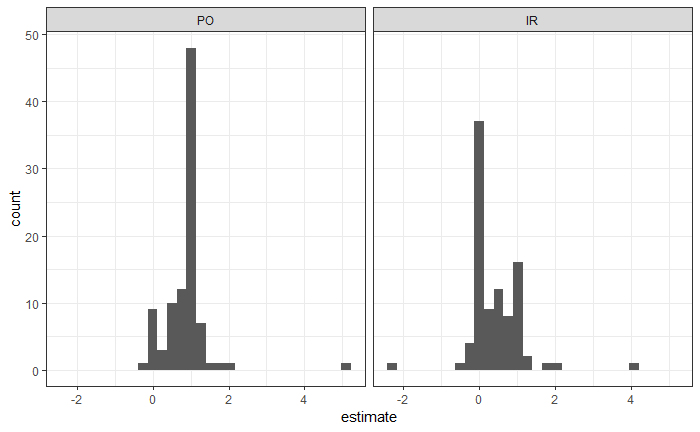

```r
ex2_slopes <- ex2_no_pooling_estimates %>%
  filter(term == "B_given_A")

ggplot(ex2_slopes, aes(estimate)) +
  geom_histogram(bins = 30) +
  facet_wrap(~ rel_cond)
```

```r
library("afex")

(a1 <- aov_car(estimate ~ rel_cond + Error(p_id/rel_cond), ex2_slopes))
```

```
Missing values for following ID(s):
219_P(if,then)
Removing those cases from the analysis.
```

```
Anova Table (Type 3 tests)

Response: estimate
    Effect    df  MSE         F ges p.value
1 rel_cond 1, 92 0.44 22.98 *** .12  <.0001
---
Signif. codes:  0 ‘***’ 0.001 ‘**’ 0.01 ‘*’ 0.05 ‘+’ 0.1 ‘ ’ 1
```

```r
emmeans::emmeans(a1, "rel_cond")
```

```
 rel_cond emmean     SE  df lower.CL upper.CL
 PO        0.870 0.0663 183    0.740    1.001
 IR        0.404 0.0663 183    0.273    0.535

Warning: EMMs are biased unless design is perfectly balanced
Confidence level used: 0.95
```

## References

- Skovgaard-Olsen, N., Singmann, H., & Klauer, K. C. (2016). The relevance effect and conditionals. *Cognition*, 150, 26-36. https://doi.org/10.1016/j.cognition.2015.12.017
- Wickham, H., & Grolemund, G. (2017). *R for Data Science: Import, Tidy, Transform, Visualize, and Model Data.* Sebastopol CA: O’Reilly.